# Lecture 14 - NESTED ANOVA

Author

Bill Perry

# Introduction

The traditional nested ANOVA approach can be implemented using a linear mixed-effects model, which provides a more flexible framework for analyzing hierarchical designs. In this case, we’ll use the `lme4` package to fit a model where treatment is a fixed effect and patch is a random effect nested within treatment.

# Data Overview

The dataframe contains 80 observations with the following variables:

- TREAT: Urchin density treatment (Control, 66% Density, 33% Density, Removed)
- PATCH: Random patches (1-16) where treatments were applied
- QUAD: Replicate quadrats within each treatment-patch combination
- ALGAE: Percentage cover of filamentous algae (response variable)

```r
# Create a summary table with flextable

summary_stats
```

```
# A tibble: 4 × 7
  TREAT           n  mean    sd    se   min   max
  <fct>       <int> <dbl> <dbl> <dbl> <dbl> <dbl>
1 Control        20   1.3  3.18 0.711     0    13
2 66% Density    20  21.6 25.1  5.62      0    79
3 33% Density    20  19   25.7  5.74      0    71
4 Removed        20  39.2 28.7  6.41      0    83
```

```r
#
# summary_stats %>%
#   select(TREAT, n, mean, sd, se, min, max) %>%
#   flextable() %>%
#   set_header_labels(
#     TREAT = "Treatment",
#     n = "N",
#     mean = "Mean",
#     sd = "SD",
#     se = "SE",
#     min = "Min",
#     max = "Max"
#   ) %>%
#   colformat_double(j = c("mean", "sd", "se", "min", "max"), digits = 2) %>%
#   autofit() %>%
#   add_header_lines("Summary statistics of algae cover (%) across treatments") %>%
#   theme_box()
```

# Mixed Model Analysis

In this experimental design, PATCH is nested within TREAT because each patch received only one treatment level. This hierarchical design is well-suited for analysis using linear mixed-effects models.

## Model Specification

We’ll use the following model specification:

$ALGAE_{ijk} = \mu + \alpha_i + \beta_{j(i)} + \epsilon_{ijk}$

Where: - $\mu$ is the overall mean - $\alpha_i$ is the fixed effect of treatment $i$ - $\beta_{j(i)}$ is the random effect of patch $j$ nested within treatment $i$ - $\epsilon_{ijk}$ is the residual error for quadrat $k$ in patch $j$ within treatment $i$

In `lme4`, this model is specified as

```r
# Fit the mixed model
mixed_model <- lmer(ALGAE ~ TREAT + (1|TREAT:PATCH), data = andrew)

# Display model summary
summary(mixed_model)
```

```
Linear mixed model fit by REML. t-tests use Satterthwaite's method [
lmerModLmerTest]
Formula: ALGAE ~ TREAT + (1 | TREAT:PATCH)
   Data: andrew

REML criterion at convergence: 682.2

Scaled residuals:
    Min      1Q  Median      3Q     Max
-1.9808 -0.3106 -0.1093  0.2831  2.5910

Random effects:
 Groups      Name        Variance Std.Dev.
 TREAT:PATCH (Intercept) 294.3    17.16
 Residual                298.6    17.28
Number of obs: 80, groups:  TREAT:PATCH, 16

Fixed effects:
                 Estimate Std. Error     df t value Pr(>|t|)
(Intercept)         1.300      9.408 12.000   0.138   0.8924
TREAT66% Density   20.250     13.305 12.000   1.522   0.1539
TREAT33% Density   17.700     13.305 12.000   1.330   0.2081
TREATRemoved       37.900     13.305 12.000   2.849   0.0147 *
---
Signif. codes:  0 '***' 0.001 '**' 0.01 '*' 0.05 '.' 0.1 ' ' 1

Correlation of Fixed Effects:
            (Intr) TREAT6D TREAT3D
TREAT66%Dns -0.707
TREAT33%Dns -0.707  0.500
TREATRemovd -0.707  0.500   0.500
```

## ANOVA Table

The ANOVA table for the mixed model:

```r
# Get ANOVA table with Type III tests
anova_table <- anova(mixed_model, type = 3)
print(anova_table)
```

```
Type III Analysis of Variance Table with Satterthwaite's method
      Sum Sq Mean Sq NumDF DenDF F value  Pr(>F)
TREAT   2434  811.33     3    12  2.7171 0.09126 .
---
Signif. codes:  0 '***' 0.001 '**' 0.01 '*' 0.05 '.' 0.1 ' ' 1
```

```r
# For comparison, also run a traditional nested ANOVA
nested_aov <- aov(ALGAE ~ TREAT + TREAT:PATCH, data = andrew)
std_summary <- summary(nested_aov)[[1]]

# Extract MS values - using exact row names
MS_treat <- std_summary["TREAT      ", "Mean Sq"]
MS_patch <- std_summary["TREAT:PATCH", "Mean Sq"]
MS_residual <- std_summary["Residuals", "Mean Sq"]

# Print MS values to check
print("MS values:")
```

```
[1] "MS values:"
```

```r
print(c(Treatment = MS_treat, Patches = MS_patch, Residual = MS_residual))
```

```
Treatment   Patches  Residual
 4809.712  1770.162   298.600
```

```r
# Extract df values
df_treat <- std_summary["TREAT      ", "Df"]
df_patch <- std_summary["TREAT:PATCH", "Df"]
df_residual <- std_summary["Residuals", "Df"]


# Calculate correct F ratios for nested design
F_treat <- MS_treat / MS_patch
F_patch <- MS_patch / MS_residual

# Calculate p-values
p_treat <- pf(F_treat, df_treat, df_patch, lower.tail = FALSE)
p_patch <- pf(F_patch, df_patch, df_residual, lower.tail = FALSE)

# Create ANOVA table
trad_anova_table <- data.frame(
  Source = c("Treatment", "Patches (treatment)", "Residual"),
  df = c(df_treat, df_patch, df_residual),
  MS = c(MS_treat, MS_patch, MS_residual),
  F = c(F_treat, F_patch, NA),
  p = c(p_treat, p_patch, NA)
)

# Format p-values
trad_anova_table$p <- ifelse(trad_anova_table$p < 0.001, "<0.001",
                       ifelse(is.na(trad_anova_table$p), NA,
                              format(trad_anova_table$p, digits = 3)))
trad_anova_table
```

```
               Source df       MS        F           p
1           Treatment  3 4809.712 2.717102 0.091262004
2 Patches (treatment) 12 1770.162 5.928207      <0.001
3            Residual 64  298.600       NA        <NA>
```

```r
# # Display traditional ANOVA table with flextable
# trad_anova_table %>%
#   flextable() %>%
#   set_header_labels(
#     Source = "Source of variation",
#     df = "df",
#     MS = "MS",
#     F = "F",
#     p = "p"
#   ) %>%
#   colformat_double(j = c("MS", "F"), digits = 2) %>%
#   autofit() %>%
#   add_header_lines("ANOVA table for nested design") %>%
#   theme_box()
```

## Variance Components

We can extract the variance components from the mixed model:

```r
# Print corrected results

# Extract variance components
vc <- VarCorr(mixed_model)
print(vc)
```

```
 Groups      Name        Std.Dev.
 TREAT:PATCH (Intercept) 17.156
 Residual                17.280
```

```r
# Extract variance components
var_comp_patch <- as.numeric(vc$`TREAT:PATCH`)
var_comp_residual <- attr(vc, "sc")^2

# Calculate percentage of total variance
total_var <- var_comp_patch + var_comp_residual
pct_patch <- var_comp_patch / total_var * 100
pct_residual <- var_comp_residual / total_var * 100

# Calculate treatment variance component
n_quad <- 5  # Number of quadrats per patch
n_patch <- 4  # Number of patches per treatment
var_comp_treatment <- (MS_treat - MS_patch) / (n_quad * n_patch)

# Format variance components for display
var_comp_treatment_display <- ifelse(var_comp_treatment < 0,
                                    paste0("(", format(abs(var_comp_treatment), digits = 2), ")"),
                                    format(var_comp_treatment, digits = 2))

# Create variance components table
var_comp_table <- data.frame(
  Source = c("Treatment", "Patches (treatment)", "Residual"),
  `Var.comp` = c(var_comp_treatment_display,
               format(var_comp_patch, digits = 2),
               format(var_comp_residual, digits = 2))
)

# Display variance components table
var_comp_table %>%
  flextable() %>%
  set_header_labels(
    Source = "Source of variation",
    Var.comp = "Variance component"
  ) %>%
  autofit() %>%
  add_header_lines("Variance components") %>%
  theme_box()
```

| Variance components Source of variation | Variance components Variance component |
| --- | --- |
| Treatment | 152 |
| Patches (treatment) | 294 |
| Residual | 299 |

```r
# Complete table with all information
complete_table <- data.frame(
  Source = c("Treatment", "Patches (treatment)", "Residual"),
  df = c(df_treat, df_patch, df_residual),
  MS = c(MS_treat, MS_patch, MS_residual),
  F = c(F_treat, F_patch, NA),
  p = c(trad_anova_table$p[1], trad_anova_table$p[2], NA),
  `Var.comp` = c(var_comp_treatment_display,
                format(var_comp_patch, digits = 2),
                format(var_comp_residual, digits = 2))
)

# Display complete table
complete_table %>%
  flextable() %>%
  set_header_labels(
    Source = "Source of variation",
    df = "df",
    MS = "MS",
    F = "F",
    p = "p",
    Var.comp = "Var. comp."
  ) %>%
  colformat_double(j = c("MS", "F"), digits = 2) %>%
  autofit() %>%
  add_header_lines("Complete ANOVA table with variance components") %>%
  theme_box()
```

| Complete ANOVA table with variance components Source of variation | Complete ANOVA table with variance components df | Complete ANOVA table with variance components MS | Complete ANOVA table with variance components F | Complete ANOVA table with variance components p | Complete ANOVA table with variance components Var. comp. |
| --- | --- | --- | --- | --- | --- |
| Treatment | 3 | 4,809.71 | 2.72 | 0.091262004 | 152 |
| Patches (treatment) | 12 | 1,770.16 | 5.93 | <0.001 | 294 |
| Residual | 64 | 298.60 |  |  | 299 |

**Interpretation of ANOVA Results**

The nested ANOVA using mixed models reveals that there was no significant effect of urchin density treatment on algae cover (F = 2.72, df = 3, 12, p = 0.0913). However, there was significant variation among patches within treatments (F = 5.93, df = 12, 64, p < 0.001).

# Lecture 14: Post-hoc Comparisons

```r
# Calculate estimated marginal means
emm <- emmeans(mixed_model, ~ TREAT)

# Display EMMs with flextable
as.data.frame(summary(emm)) %>%
  flextable() %>%
  set_header_labels(
    TREAT = "Treatment",
    emmean = "Estimated Marginal Mean",
    SE = "Standard Error",
    df = "df",
    lower.CL = "Lower CL",
    upper.CL = "Upper CL"
  ) %>%
  colformat_double(j = c("emmean", "SE", "lower.CL", "upper.CL"), digits = 2) %>%
  autofit() %>%
  add_header_lines("Estimated marginal means for each treatment") %>%
  theme_box()
```

| Estimated marginal means for each treatment Treatment | Estimated marginal means for each treatment Estimated Marginal Mean | Estimated marginal means for each treatment Standard Error | Estimated marginal means for each treatment df | Estimated marginal means for each treatment Lower CL | Estimated marginal means for each treatment Upper CL |
| --- | --- | --- | --- | --- | --- |
| Control | 1.30 | 9.41 | 12 | -19.20 | 21.80 |
| 66% Density | 21.55 | 9.41 | 12 | 1.05 | 42.05 |
| 33% Density | 19.00 | 9.41 | 12 | -1.50 | 39.50 |
| Removed | 39.20 | 9.41 | 12 | 18.70 | 59.70 |

# Lecture 14: Tukey Pairwise Comparisons

```r
# Pairwise comparisons with Tukey adjustment
pairs <- pairs(emm, adjust = "tukey")
pairs
```

```
 contrast                  estimate   SE df t.ratio p.value
 Control - 66% Density       -20.25 13.3 12  -1.522  0.4553
 Control - 33% Density       -17.70 13.3 12  -1.330  0.5625
 Control - Removed           -37.90 13.3 12  -2.849  0.0615
 66% Density - 33% Density     2.55 13.3 12   0.192  0.9974
 66% Density - Removed       -17.65 13.3 12  -1.327  0.5646
 33% Density - Removed       -20.20 13.3 12  -1.518  0.4573

Degrees-of-freedom method: kenward-roger
P value adjustment: tukey method for comparing a family of 4 estimates
```

```r
# # Display pairwise comparisons with flextable
# as.data.frame(summary(pairs)) %>%
#   flextable() %>%
#   set_header_labels(
#     contrast = "Contrast",
#     estimate = "Estimate",
#     SE = "Standard Error",
#     df = "df",
#     t.ratio = "t ratio",
#     p.value = "p-value"
#   ) %>%
#   colformat_double(j = c("estimate", "SE", "t.ratio", "p.value"), digits = 3) %>%
#   autofit() %>%
#   add_header_lines("Pairwise comparisons between treatments (Tukey-adjusted)") %>%
#   theme_box()
```

# Lecture 14: Letter Display

```r
# Extract compact letter display for plotting
cld <- multcomp::cld(emm, alpha = 0.05, Letters = letters)

cld
```

```
 TREAT       emmean   SE df lower.CL upper.CL .group
 Control        1.3 9.41 12   -19.20     21.8  a
 33% Density   19.0 9.41 12    -1.50     39.5  a
 66% Density   21.6 9.41 12     1.05     42.0  a
 Removed       39.2 9.41 12    18.70     59.7  a

Degrees-of-freedom method: kenward-roger
Confidence level used: 0.95
P value adjustment: tukey method for comparing a family of 4 estimates
significance level used: alpha = 0.05
NOTE: If two or more means share the same grouping symbol,
      then we cannot show them to be different.
      But we also did not show them to be the same.
```

```r
# # Display CLD with flextable
# as.data.frame(cld) %>%
#   flextable() %>%
#   set_header_labels(
#     TREAT = "Treatment",
#     emmean = "Estimated Marginal Mean",
#     SE = "Standard Error",
#     df = "df",
#     lower.CL = "Lower CL",
#     upper.CL = "Upper CL",
#     .group = "Group"
#   ) %>%
#   colformat_double(j = c("emmean", "SE", "lower.CL", "upper.CL"), digits = 2) %>%
#   autofit() %>%
#   add_header_lines("Compact letter display of treatment means") %>%
#   theme_box()
```

# Assumption Testing

For valid inference from mixed models, several assumptions must be met. We test these assumptions below.

## Normality of Residuals

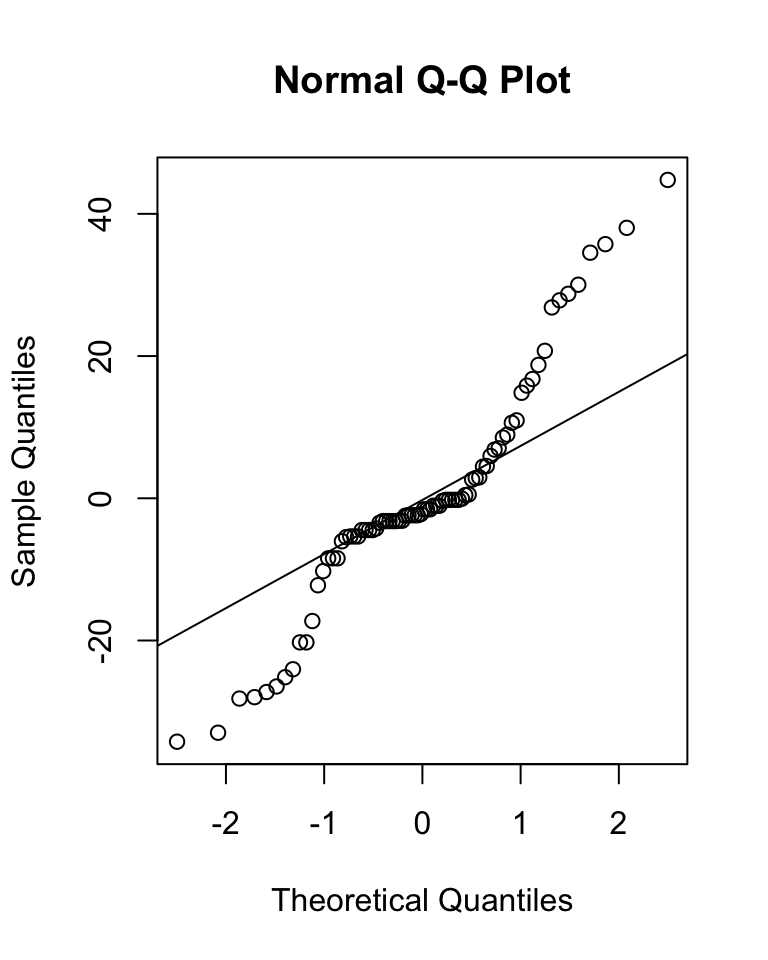

```r
# QQ plot of residuals
qqnorm(resid(mixed_model))
qqline(resid(mixed_model))
```

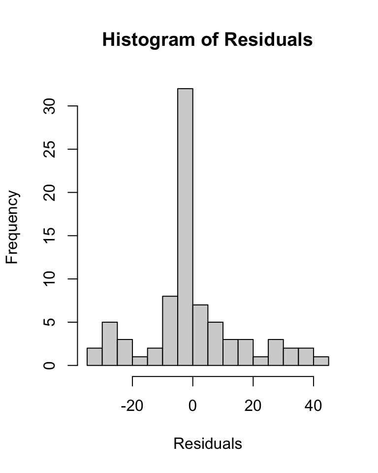

```r
# Histogram of residuals
hist(resid(mixed_model), main = "Histogram of Residuals",
     xlab = "Residuals", breaks = 15)
```

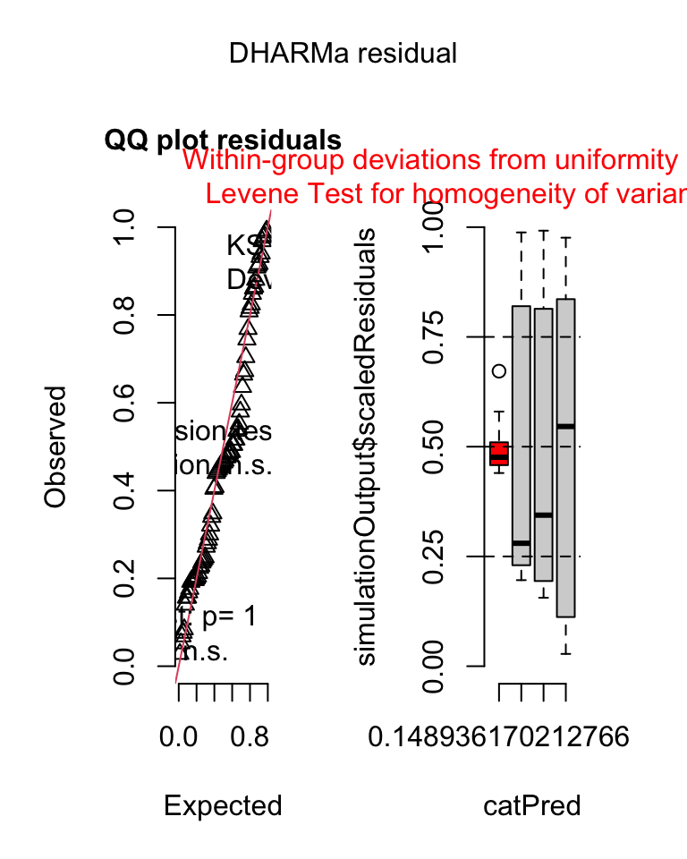

```r
# More advanced residual diagnostics using DHARMa
sim_residuals <- simulateResiduals(fittedModel = mixed_model)
plot(sim_residuals)
```

## Homogeneity of Variance

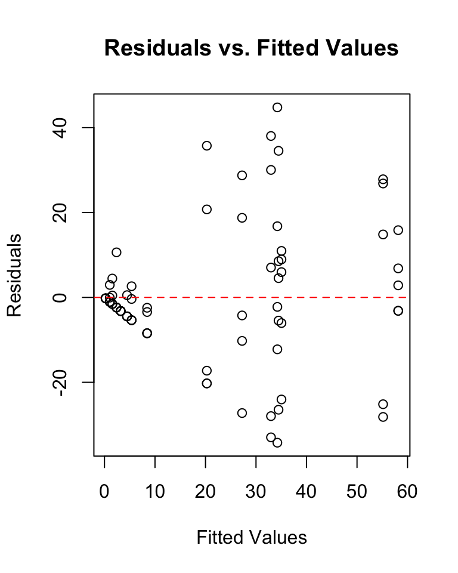

```r
# Residuals vs. fitted values plot
plot(fitted(mixed_model), resid(mixed_model),
     xlab = "Fitted Values", ylab = "Residuals",
     main = "Residuals vs. Fitted Values")
abline(h = 0, lty = 2, col = "red")
```

```r
# Levene's test for homogeneity of variance
levene_test <- leveneTest(ALGAE ~ TREAT, data = andrew)
levene_test
```

```
Levene's Test for Homogeneity of Variance (center = median)
      Df F value     Pr(>F)
group  3  8.1694 0.00008785 ***
      76
---
Signif. codes:  0 '***' 0.001 '**' 0.01 '*' 0.05 '.' 0.1 ' ' 1
```

**Interpretation of Assumption Tests**

The Q-Q plot shows some deviation from normality, particularly in the tails, and Levene’s test indicates significant heterogeneity of variances across treatments (F = 8.17, p < 0.001). As noted in the original analysis, there were “large differences in within-cell variances” in this dataset, and transformations did not improve variance homogeneity.

However, mixed models are generally robust to moderate violations of assumptions, especially with balanced designs. Since transformations were not effective in improving the data properties, analyzing the untransformed data is a reasonable approach in this case.

# Post-hoc Comparisons

Although the main effect of treatment was not significant in the nested ANOVA (p = 0.0913), we can still examine the mean differences between treatments to understand patterns in the data.

```r
# Calculate estimated marginal means
emm <- emmeans(mixed_model, ~ TREAT)
emm
```

```
 TREAT       emmean   SE df lower.CL upper.CL
 Control        1.3 9.41 12   -19.20     21.8
 66% Density   21.6 9.41 12     1.05     42.0
 33% Density   19.0 9.41 12    -1.50     39.5
 Removed       39.2 9.41 12    18.70     59.7

Degrees-of-freedom method: kenward-roger
Confidence level used: 0.95
```

```r
# Pairwise comparisons with Tukey adjustment
pairs <- pairs(emm, adjust = "tukey")
pairs
```

```
 contrast                  estimate   SE df t.ratio p.value
 Control - 66% Density       -20.25 13.3 12  -1.522  0.4553
 Control - 33% Density       -17.70 13.3 12  -1.330  0.5625
 Control - Removed           -37.90 13.3 12  -2.849  0.0615
 66% Density - 33% Density     2.55 13.3 12   0.192  0.9974
 66% Density - Removed       -17.65 13.3 12  -1.327  0.5646
 33% Density - Removed       -20.20 13.3 12  -1.518  0.4573

Degrees-of-freedom method: kenward-roger
P value adjustment: tukey method for comparing a family of 4 estimates
```

```r
# Compact letter display
cld <- multcomp::cld(emm, alpha = 0.05, Letters = letters)
cld
```

```
 TREAT       emmean   SE df lower.CL upper.CL .group
 Control        1.3 9.41 12   -19.20     21.8  a
 33% Density   19.0 9.41 12    -1.50     39.5  a
 66% Density   21.6 9.41 12     1.05     42.0  a
 Removed       39.2 9.41 12    18.70     59.7  a

Degrees-of-freedom method: kenward-roger
Confidence level used: 0.95
P value adjustment: tukey method for comparing a family of 4 estimates
significance level used: alpha = 0.05
NOTE: If two or more means share the same grouping symbol,
      then we cannot show them to be different.
      But we also did not show them to be the same.
```

# Visualization

```r
# Create boxplot with jittered points
ggplot_boxplot <- ggplot(andrew, aes(x = TREAT, y = ALGAE, fill = TREAT)) +
  geom_boxplot(alpha = 0.7, outlier.shape = NA) +
  geom_jitter(width = 0.2, alpha = 0.4, size = 1) +
  scale_fill_viridis_d(option = "D", end = 0.85) +
  labs(
    title = "Urchin Density effect on Algae Cover",
    x = "Urchin Density ",
    y = "Algae Cover (%)",
    caption = "Figure 1: Boxplots showing the distribution of algal cover across urchin density.\nDespite visual differences, the treatment effect was not statistically significant (p = 0.091)."
  ) +
  theme_minimal() +
  theme(
    legend.position = "none",
    plot.title = element_text(face = "bold", size = 14),
    axis.title = element_text(face = "bold", size = 12),
    axis.text = element_text(size = 10),
    plot.caption = element_text(hjust = 0, face = "italic", size = 10)
  )

# Create means plot with error bars
means_plot <- ggplot(summary_stats, aes(x = TREAT, y = mean, group = 1)) +
  geom_point(size = 3, shape = 21, fill = "white") +
  geom_errorbar(aes(ymin = mean - se, ymax = mean + se), width = 0.2) +
  labs(
    title = "Mean Algae Cover by Urchin Density",
    x = "Urchin Density",
    y = "Algae Cover (%)",
    caption = "Figure 2: Mean (± SE) percentage cover of algae across urchin density treatments."
  ) +
  theme_minimal() +
  theme(
    plot.title = element_text(face = "bold", size = 14),
    axis.title = element_text(face = "bold", size = 12),
    axis.text = element_text(size = 10),
    plot.caption = element_text(hjust = 0, face = "italic", size = 10)
  )
```

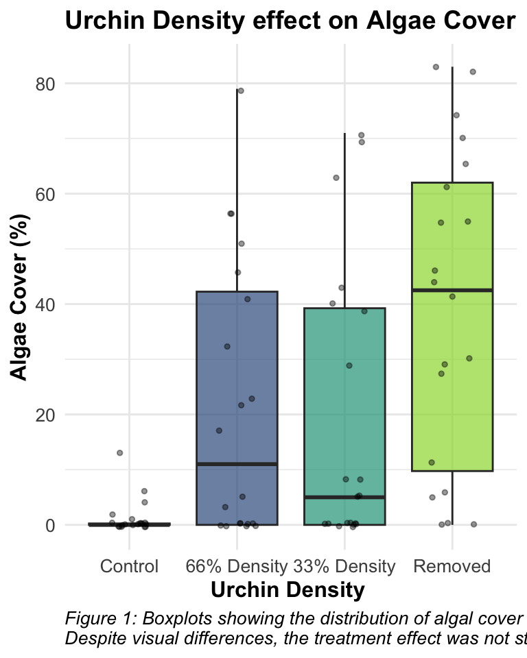

```r
# Display plots
ggplot_boxplot
```

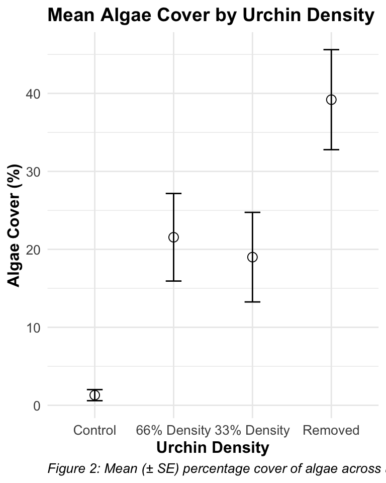

```r
means_plot
```

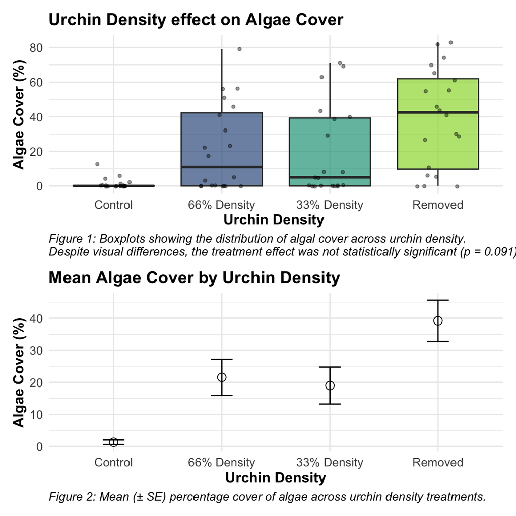

```r
# Combined plot using patchwork
ggplot_boxplot + means_plot + plot_layout(ncol = 1)
```

# Discussion

**Scientific Interpretation**

Our mixed model analysis of the nested design revealed substantial spatial heterogeneity in algae cover, with significant variation among patches within each treatment (p < 0.001). Surprisingly, the effect of urchin density treatments on filamentous algae cover was not statistically significant at the α = 0.05 level (p = 0.091), despite apparent trends in the data.

The substantial variance component associated with patches nested within treatments (294.31, approximately 39.5% of total variance) underscores the importance of spatial heterogeneity in structuring algal communities. This finding highlights the necessity of accounting for spatial variability when designing and analyzing ecological field experiments.

From an ecological perspective, these results suggest that while sea urchins may influence algal communities through grazing, local environmental factors and patch-specific conditions play a dominant role in determining algae cover. This has important implications for ecosystem management, as it indicates that the effects of urchin density manipulations may be context-dependent and influenced by local environmental conditions.

# Comparison with Traditional Nested ANOVA

The linear mixed model approach provides similar results to the traditional nested ANOVA approach. The main advantage of the mixed model is the more elegant handling of random effects and the extensive diagnostic tools available through packages like DHARMa.

The mixed model approach confirms that:

1. Treatment effects are not significant (p = 0.091)
2. Patches within treatments show significant variation (p < 0.001)
3. The variance components are similar to those from the traditional approach

In both methods, the key ecological finding is the strong spatial heterogeneity in algal cover that overrides the grazing effect of urchins at different densities.

# References

Andrew, N. L., & Underwood, A. J. (1993). Density-dependent foraging in the sea urchin Centrostephanus rodgersii on shallow subtidal reefs in New South Wales, Australia. Marine Ecology Progress Series, 99, 89-98.

Quinn, G. P., & Keough, M. J. (2002). Experimental design and data analysis for biologists. Cambridge University Press.

Back to top